# Red Wine Quality Analysis by Karun Gahlawat

```
## [1] "data complete"
```

> **Brief Summary of Data**:

1 - fixed acidity: most acids involved with wine or fixed or nonvolatile (do not evaporate readily)

2 - volatile acidity: the amount of acetic acid in wine, which at too high of levels can lead to an unpleasant, vinegar taste

3 - citric acid: found in small quantities, citric acid can add ‘freshness’ and flavor to wines

4 - residual sugar: the amount of sugar remaining after fermentation stops, it’s rare to find wines with less than 1 gram/liter and wines with greater than 45 grams/liter are considered sweet

5 - chlorides: the amount of salt in the wine

6 - free sulfur dioxide: the free form of SO2 exists in equilibrium between molecular SO2 (as a dissolved gas) and bisulfite ion; it prevents microbial growth and the oxidation of wine

7 - total sulfur dioxide: amount of free and bound forms of S02; in low concentrations, SO2 is mostly undetectable in wine, but at free SO2 concentrations over 50 ppm, SO2 becomes evident in the nose and taste of wine

8 - density: the density of water is close to that of water depending on the percent alcohol and sugar content

9 - pH: describes how acidic or basic a wine is on a scale from 0 (very acidic) to 14 (very basic); most wines are between 3-4 on the pH scale

10 - sulphates: a wine additive which can contribute to sulfur dioxide gas (S02) levels, wich acts as an antimicrobial and antioxidant

11 - alcohol: the percent alcohol content of the wine Output variable (based on sensory data):

12 - quality (score between 0 and 10)

- We will explore this data with each feature and will try to explain what features contribute to a good rating.

# Univariate Plots Section

```
## [1] "fixed.acidity"
```

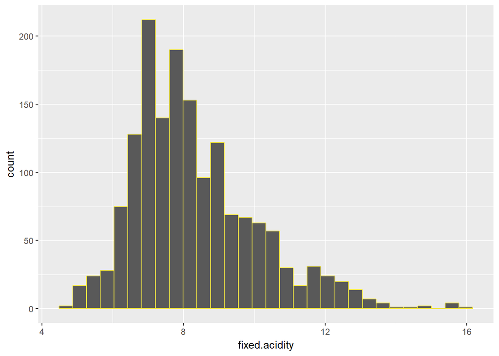

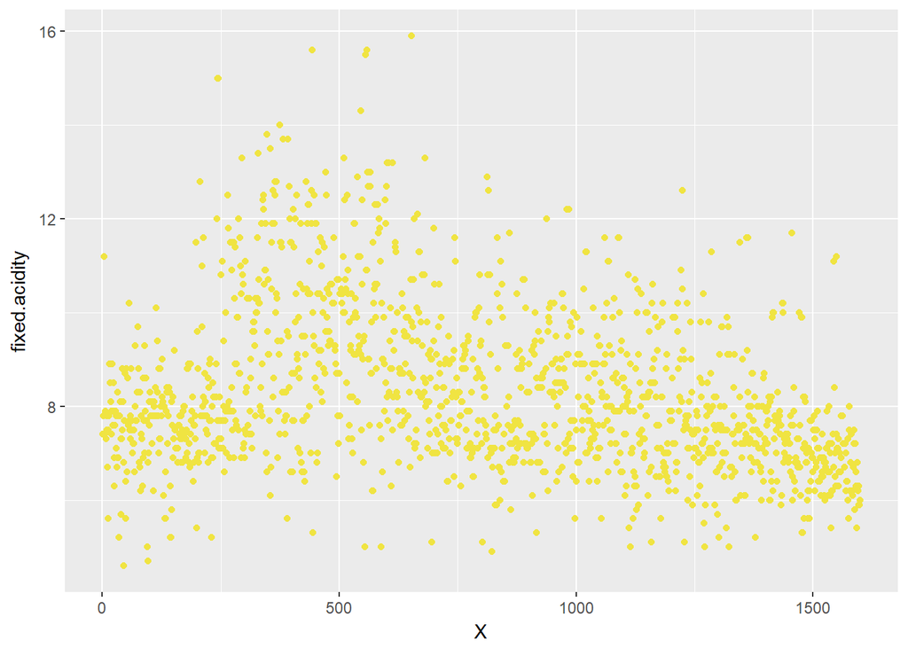

```
## [1] "volatile.acidity"
```

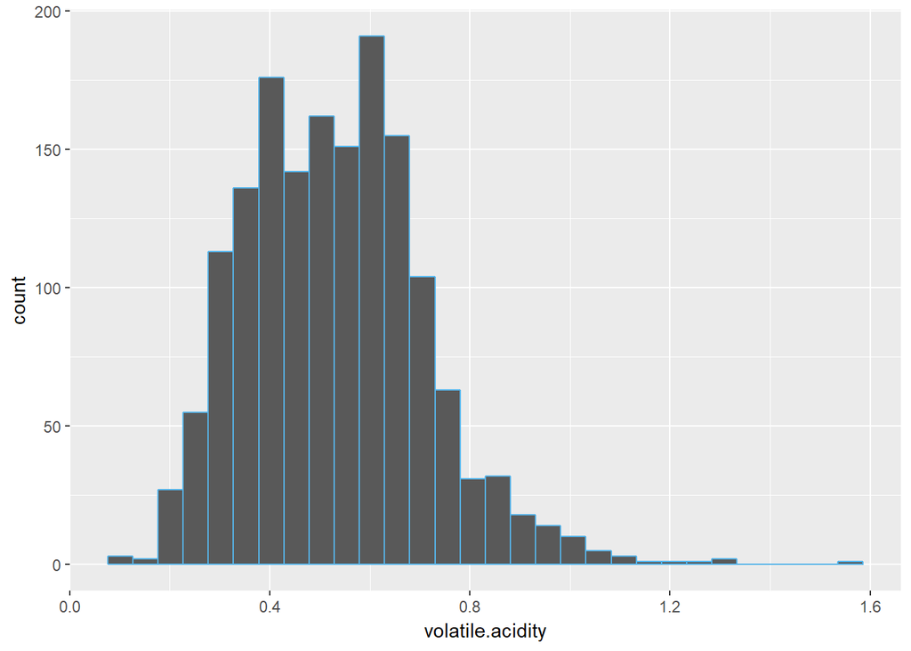

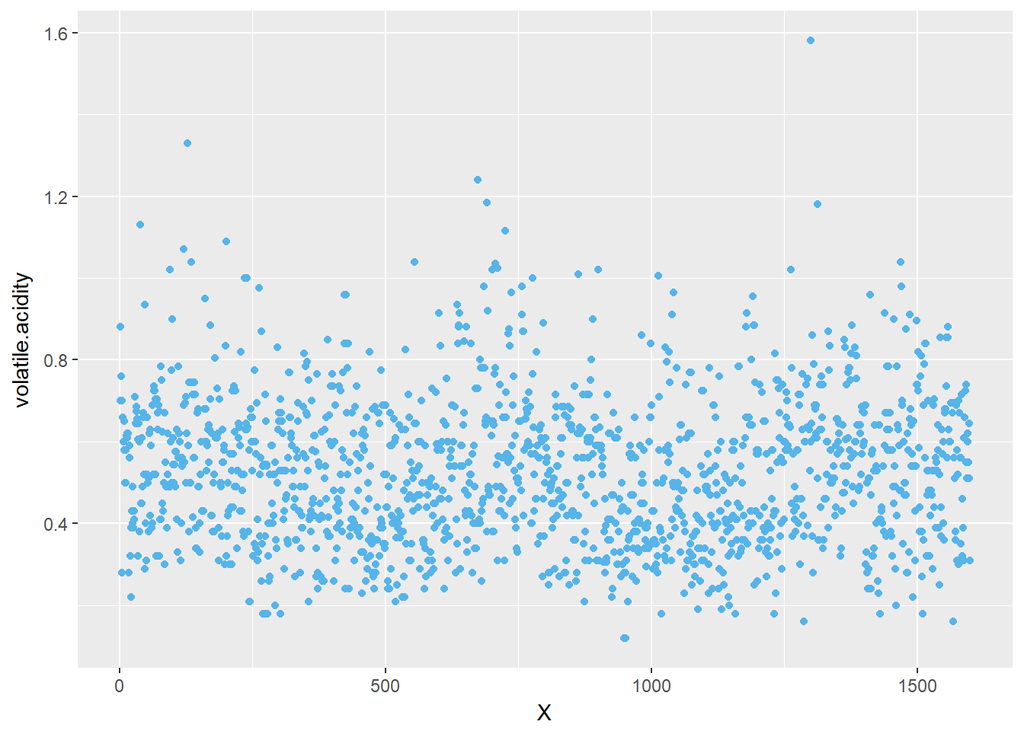

```
## [1] "citric.acid"
```

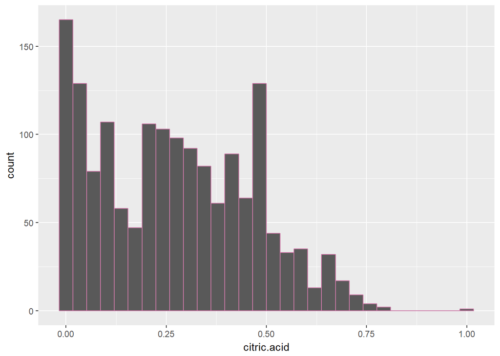

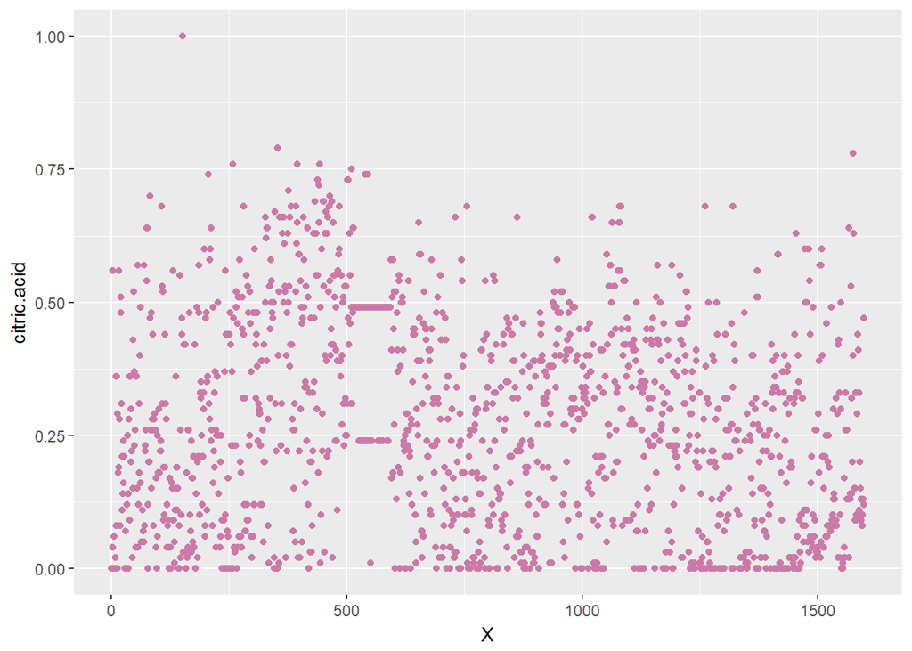

```
## [1] "residual.sugar"
```

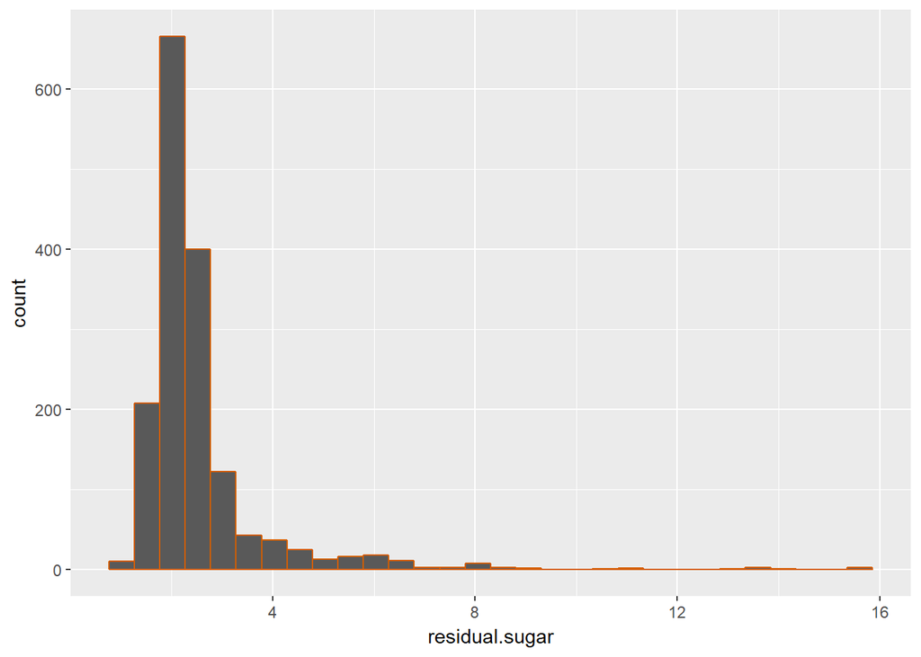

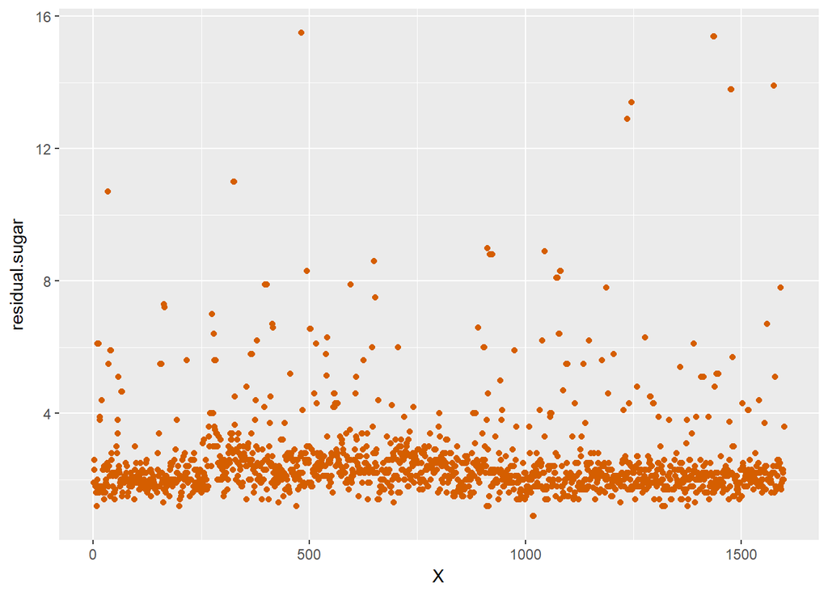

```
## [1] "chlorides"
```

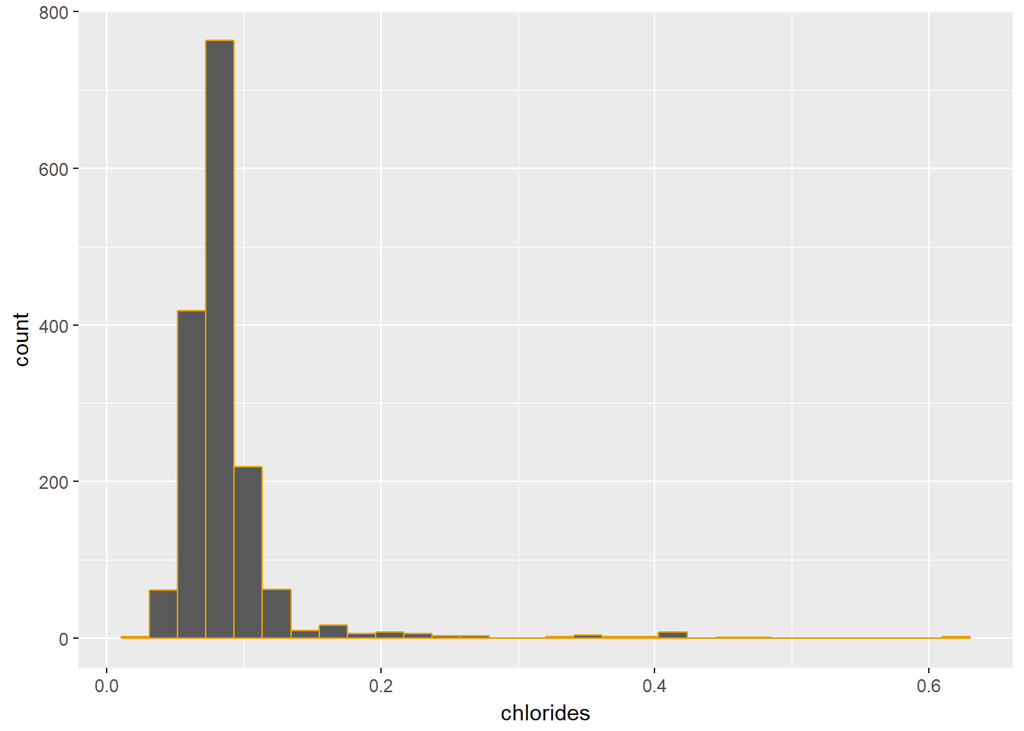

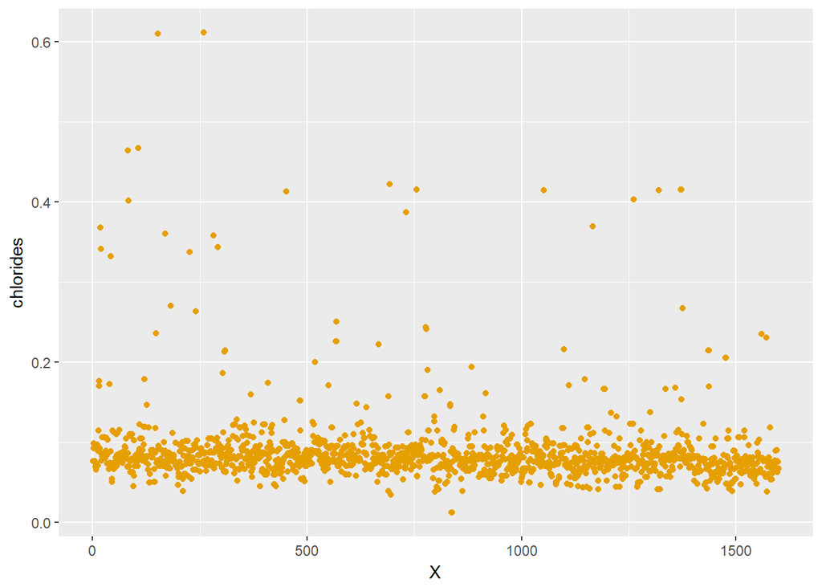

```
## [1] "free.sulfur.dioxide"
```

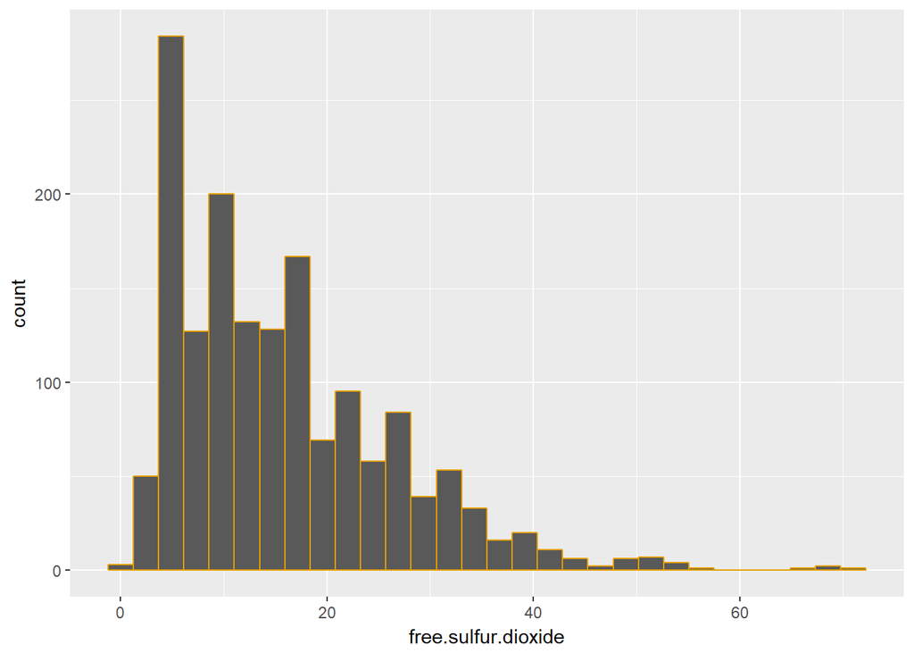

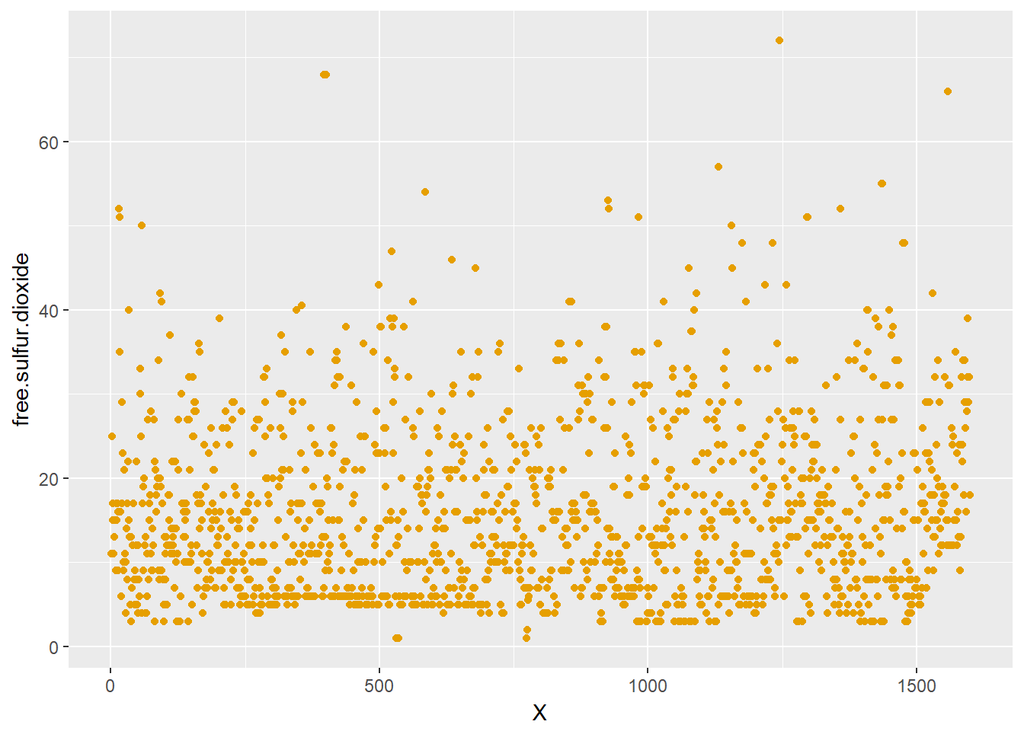

```
## [1] "total.sulfur.dioxide"
```

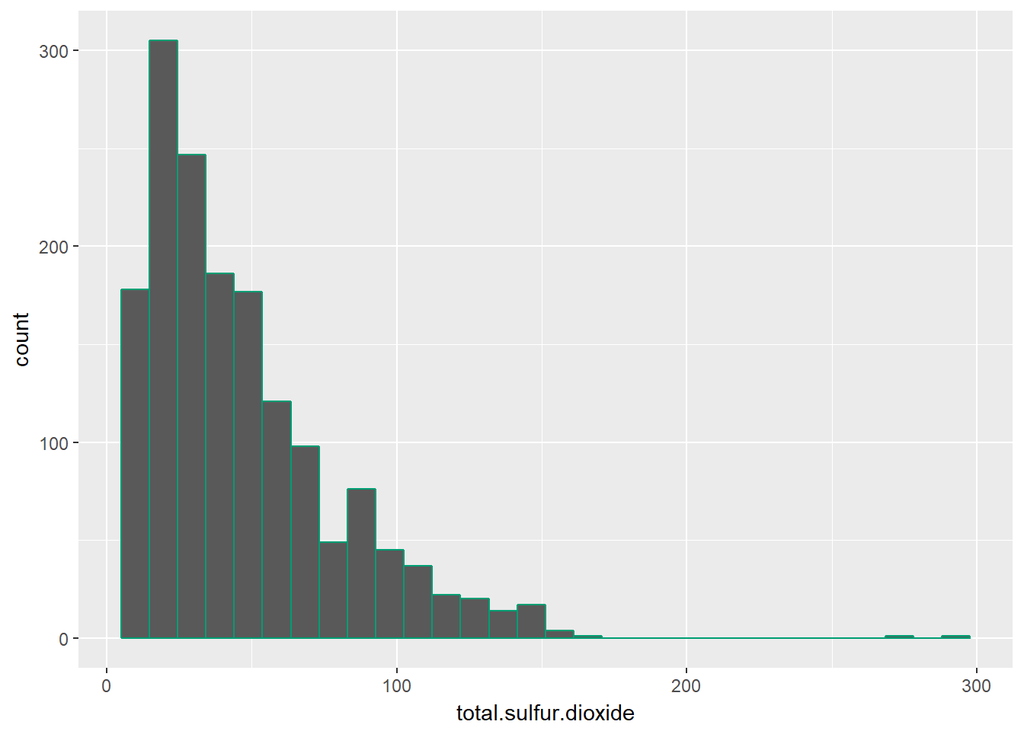

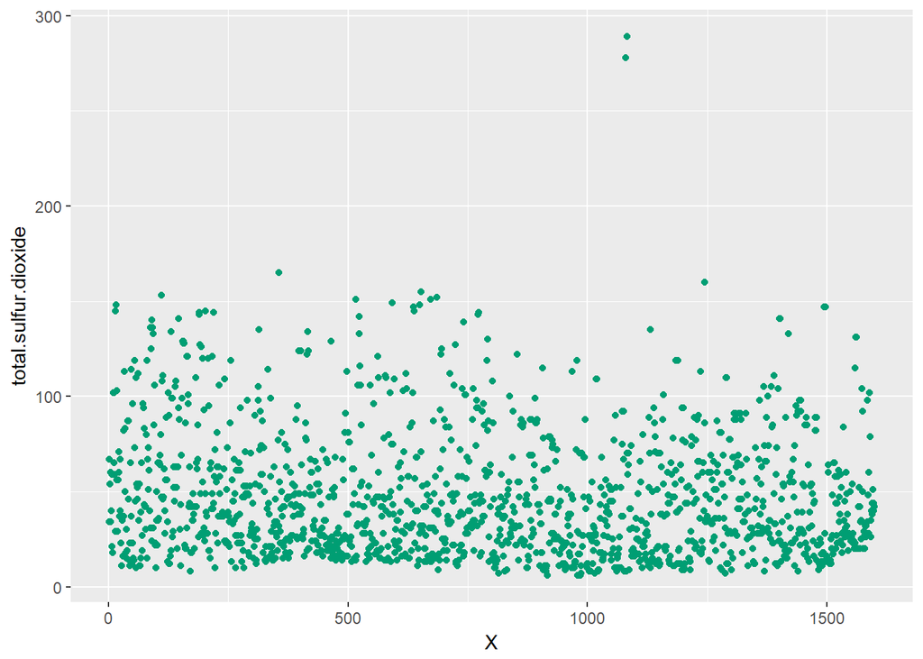

```
## [1] "density"
```

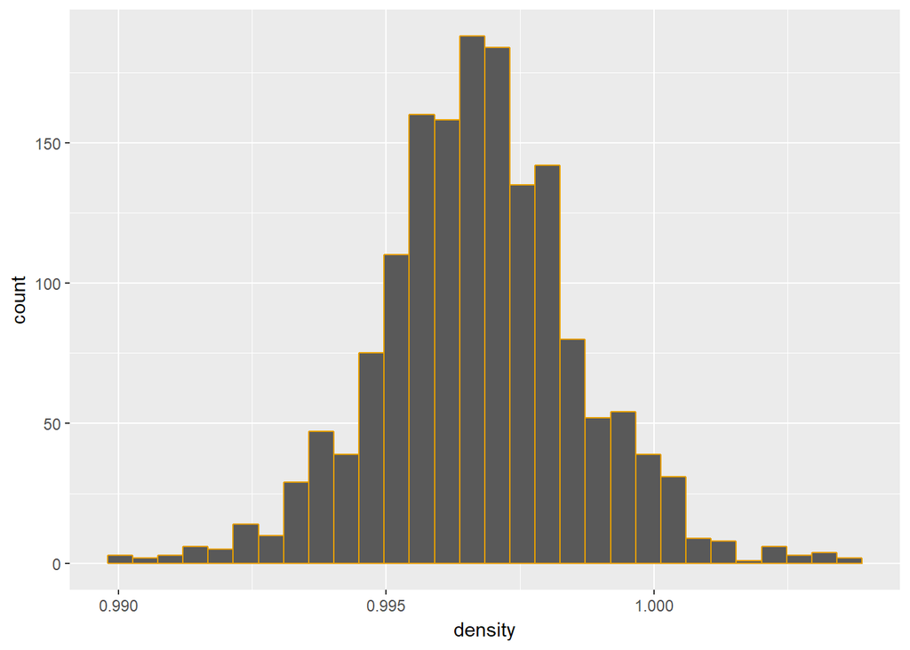

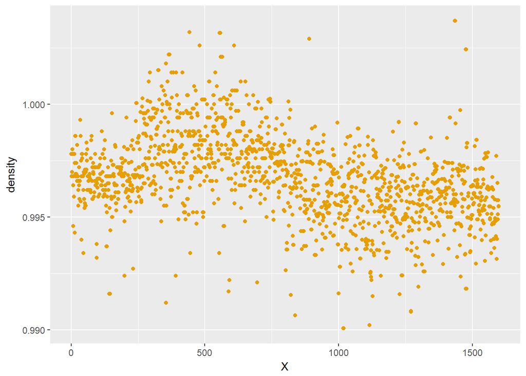

```
## [1] "pH"
```

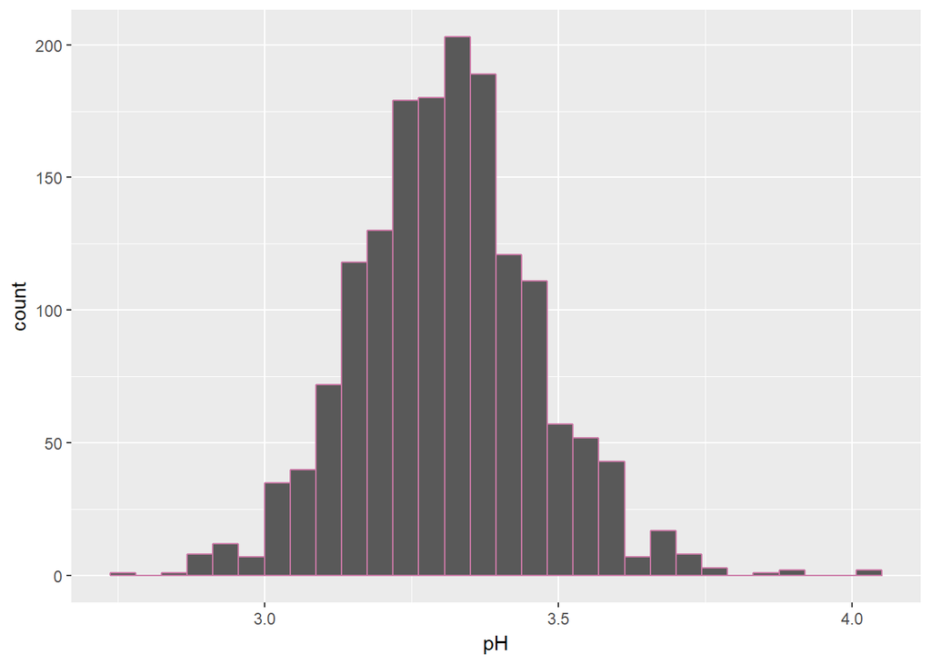

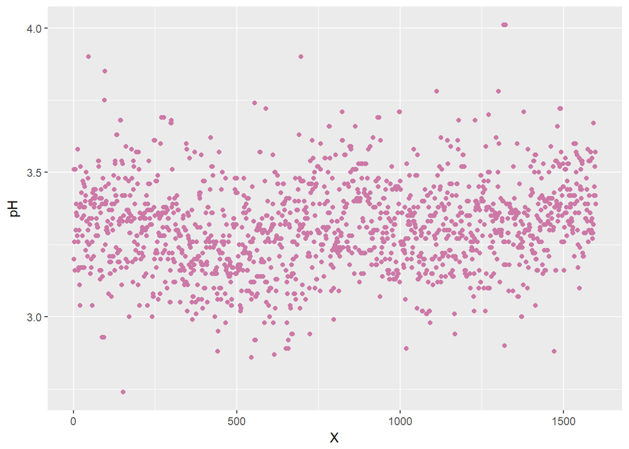

```
## [1] "sulphates"
```

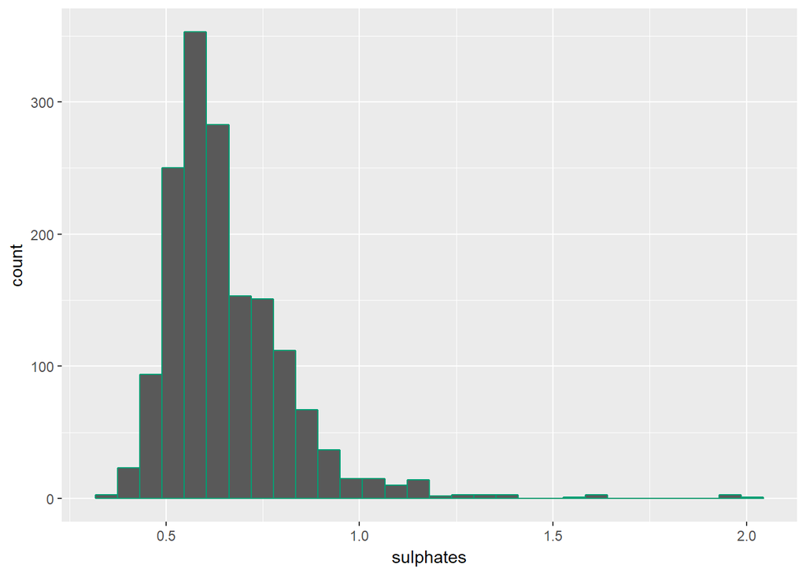

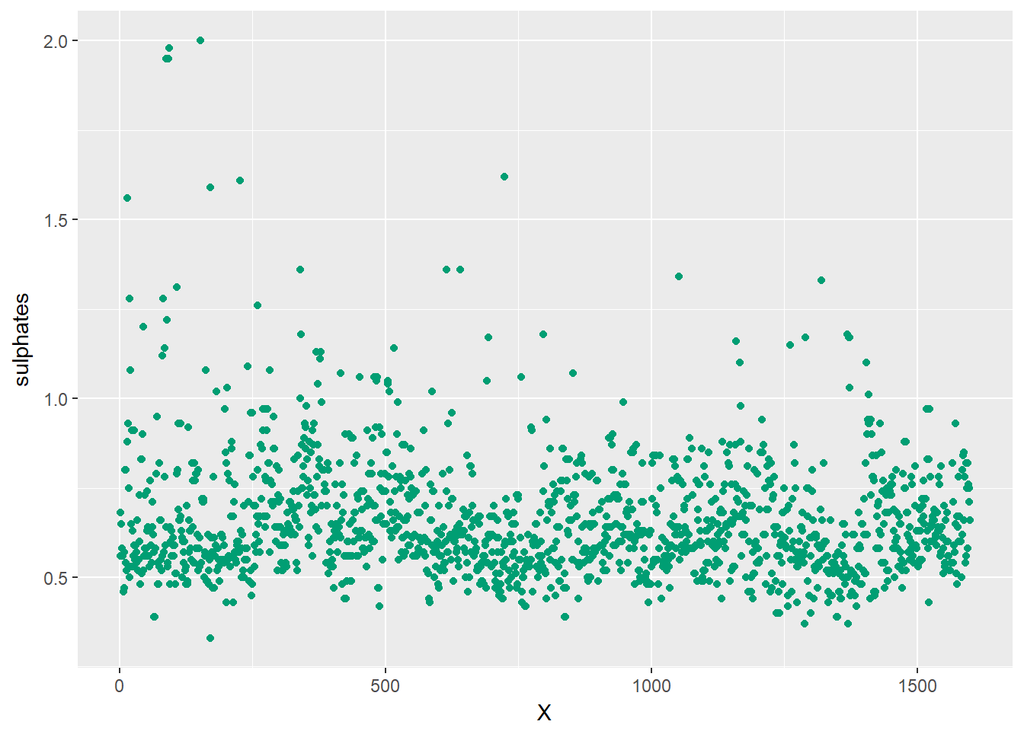

```
## [1] "alcohol"
```

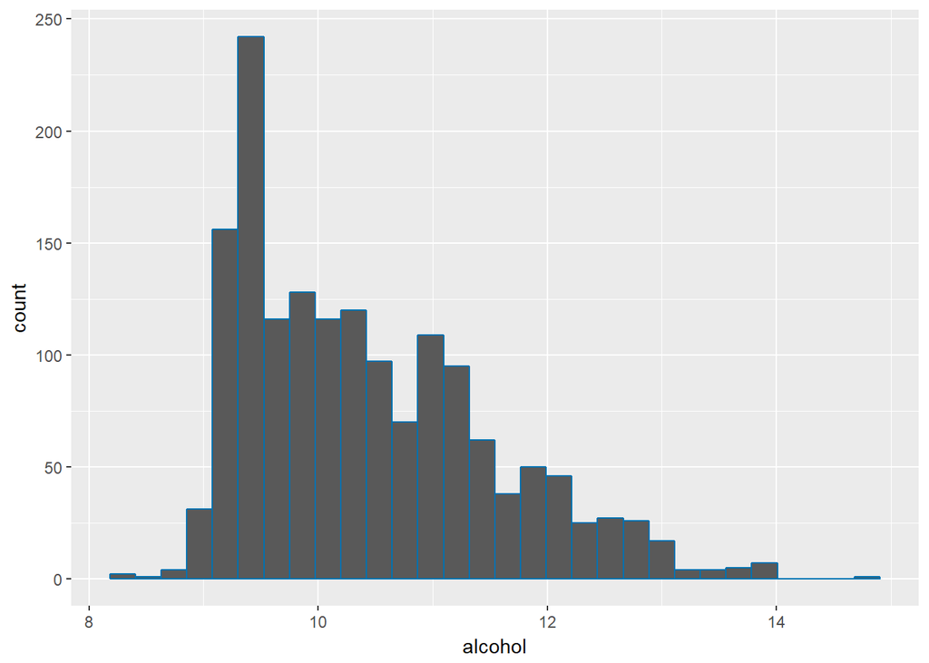

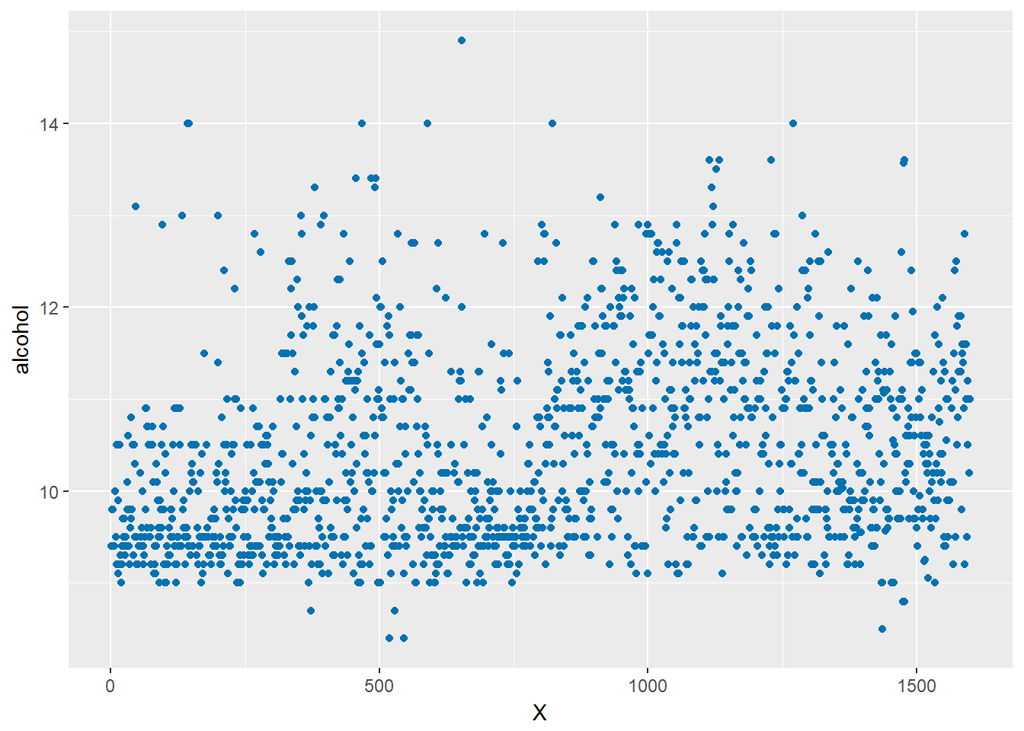

```
## [1] "quality"
```

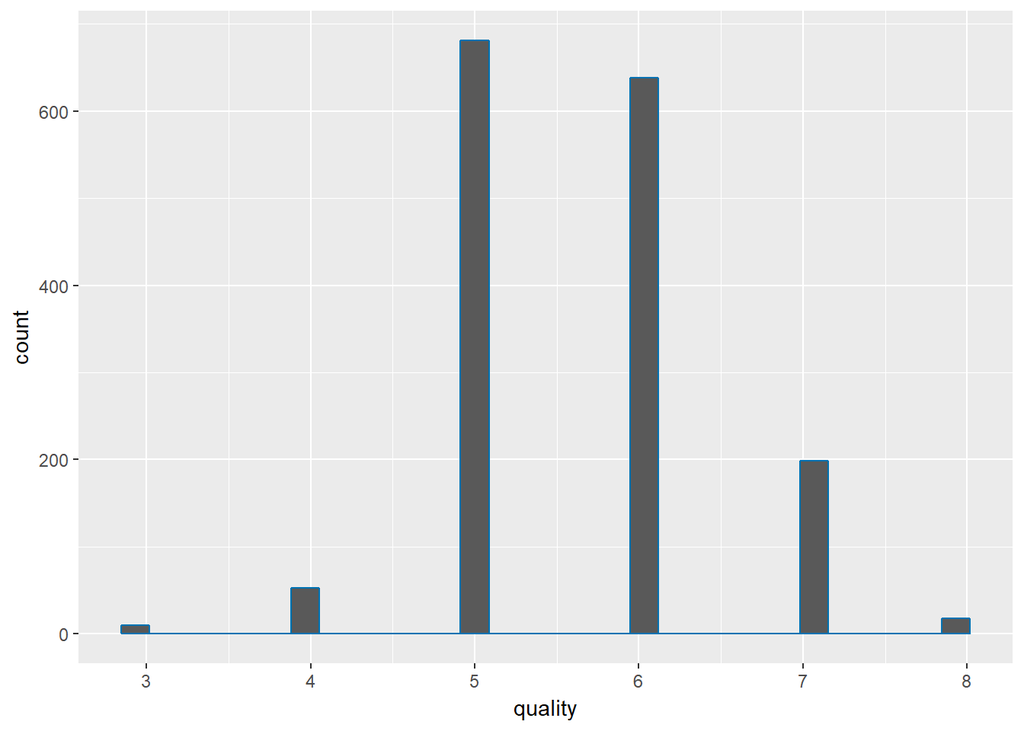

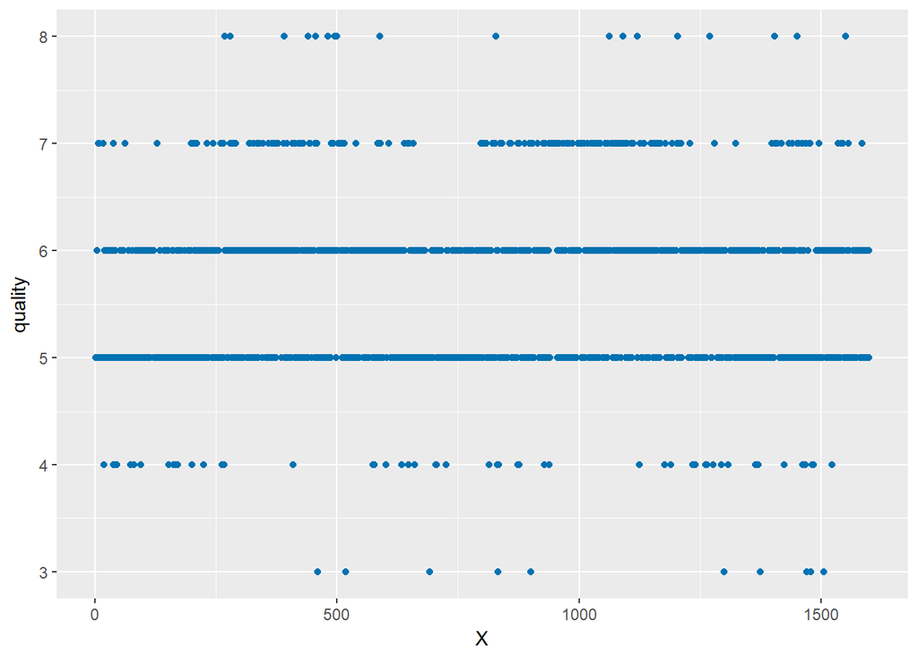

# Univariate Analysis

> fixed.acidity is positively skewed near normally distributed with large right tail. The majority of reading center around 6-8 with some values as far as 16.

> volatile.acidity is centered around 0.4 and 0.6. Some outliers show as far as 1.5.

> citric.acid is not centered around a single value but spread over a broad range. Largest counts near 0 and 0.5. Some outliers around 1. Wow! 1? Might as well drink straight from a lime!!!

> residual.sugar is centered around 2 with some outliers as far as 8-16. Most observations are in the range 1-3.

> total.sulfur.dioxide majority of observations lie within 0-50 and are not centered. Outliers go as far as 300!. Wow that is a lot of variation! Wonder if these high values should be ignored in analysis?

> density looks centered aroun .9975 with values almost symetrical both below and above this value but most observations near this value. Interesting… wonder if this factor is most responsible for quality given its symetry?

> pH like density this one is also centered and almost symetrical. Although it seem to have broader outliers than density. Wonder if this factor as well influences quality more than others? Or whether this factor has to be around certain value (3.25 in this case) to be drinkable? Should be interesting to find out!

> sulphates is centered around 0.5- 0.6 but are more spread out to the right (higher values) with some outliers as far as 2. Wonder wines with higher quality have low or high sulpfur content?

> quality ratings are in this order 5, 6, 7, 4, 8 and 3. Most observation fall in rating 5, then in rating 6, then in rating 7 and so on. We see none at far ends (0, 10). It is interesting to see how many fall in the mid range.

### What is the structure of your dataset?

> data set is set of ~ 1600 observations with 11 features. It is a two dimensional table with last column as the output column that classify each observation into 10 possible categories. Data is tidy as in all rows are observations and each column is a feature. No duplicates and no missing or NAs. It appears that this data is almost ready for training.

### What other features in the dataset do you think will help support your investigation into your feature(s) of interest?

> I compared means of features with means of features where qaulity is 8 or greater. It gave some interesting insight on this dataset that most features have mean close to the quality means. There are a few features that stand a bit apart which could indicate some importance towards quality of wine.

### Did you create any new variables from existing variables in the dataset?

> No. There are plenty of variables to explore this data set of size 1600 rows.

### Of the features you investigated, were there any unusual distributions? Did you perform any operations on the data to tidy, adjust, or change the form of the data? If so, why did you do this?

> I did not tidy any further this data base although I did filter some things out to explain some factors.

# Bivariate Plots Section

```
##                      MeanQuality        Mean
## fixed.acidity         8.56666667  8.31963727
## volatile.acidity      0.42333333  0.52782051
## citric.acid           0.39111111  0.27097561
## residual.sugar        2.57777778  2.53880550
## chlorides             0.06844444  0.08746654
## free.sulfur.dioxide  13.27777778 15.87492183
## total.sulfur.dioxide 33.44444444 46.46779237
## density               0.99521222  0.99674668
## pH                    3.26722222  3.31111320
## sulphates             0.76777778  0.65814884
## alcohol              12.09444444 10.42298311
## quality               8.00000000  5.63602251
```

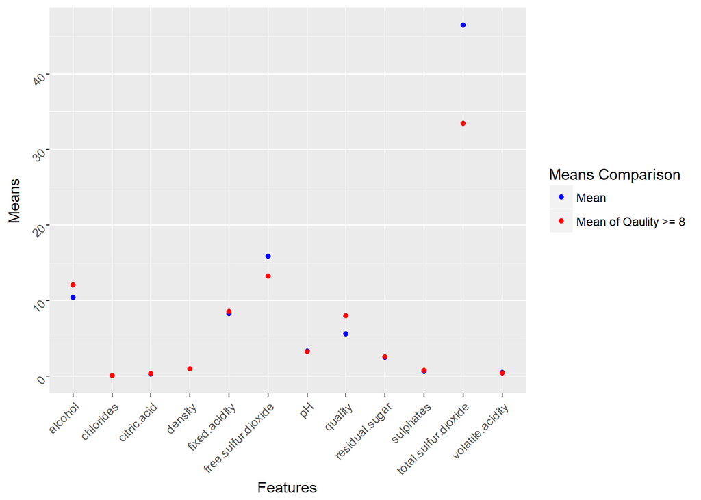

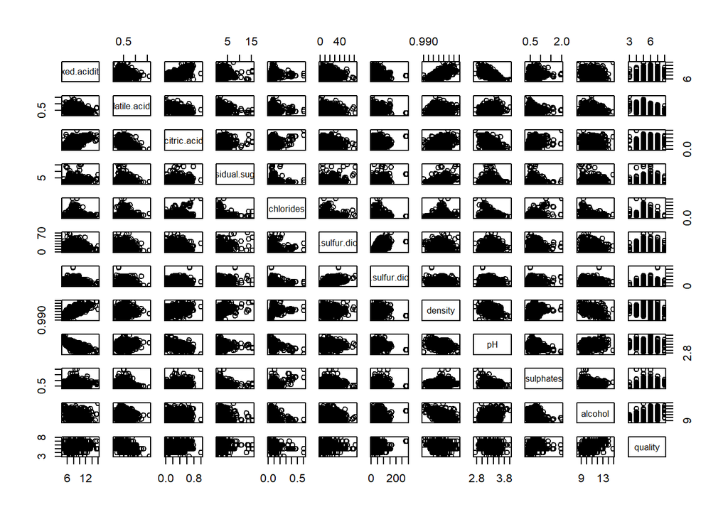

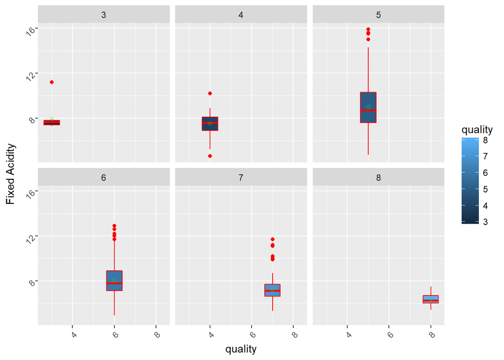

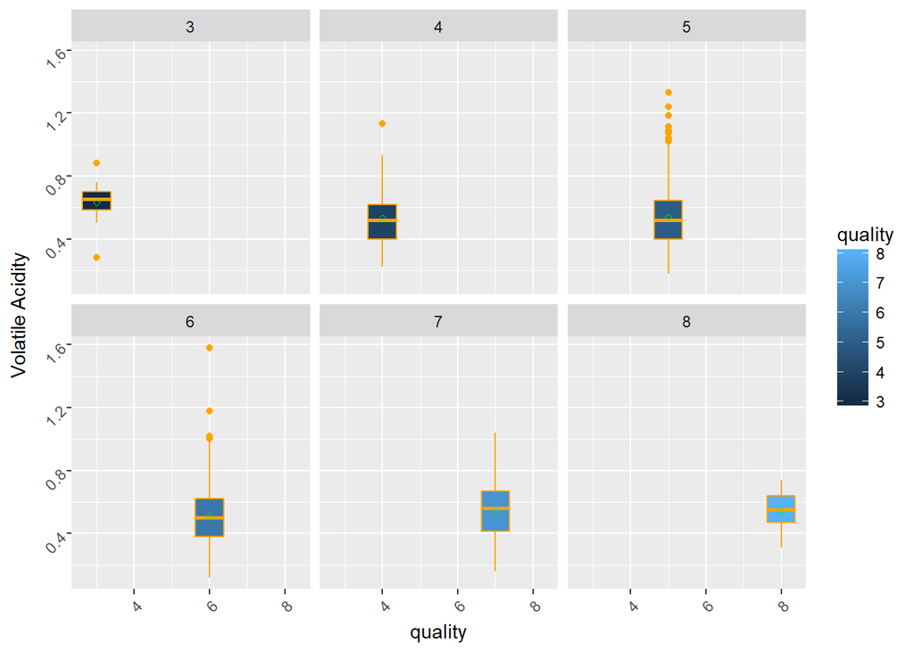

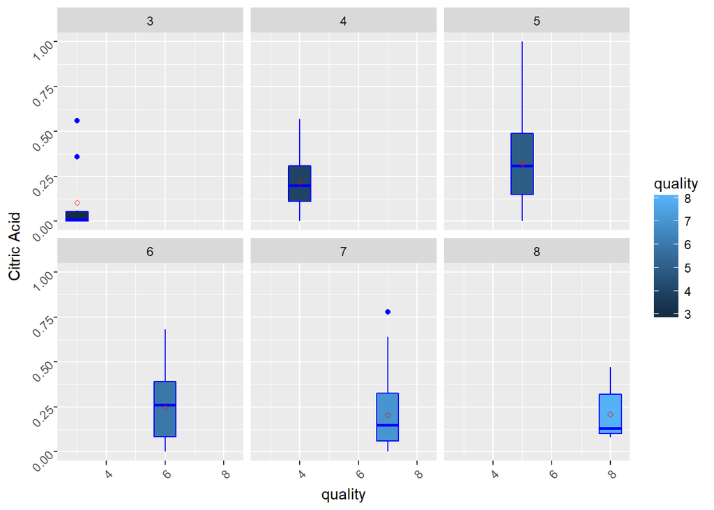

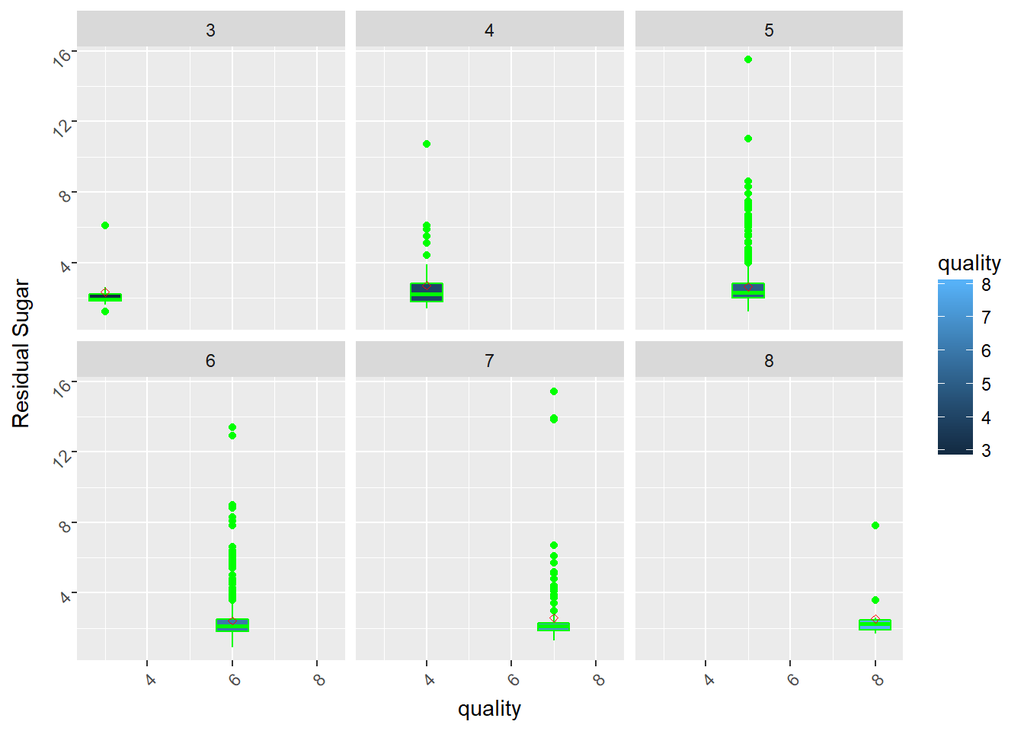

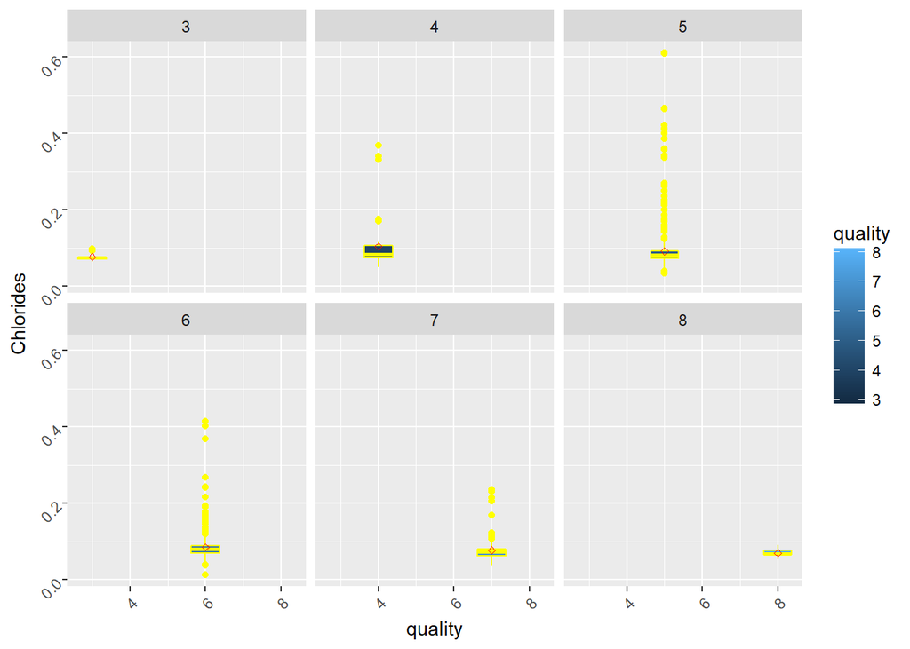

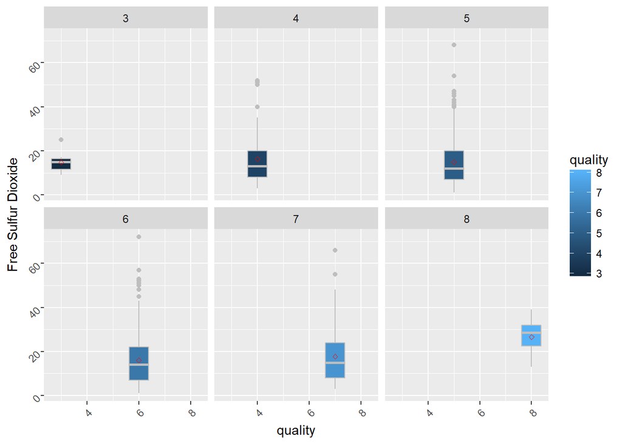